# bootcamp

# 課題１

## 1. 課題の概要

移民に関する連邦議会での演説に関して、国ごとの言及回数を集計すること

## 2. コード

### 2.1. quantedaを使用したVer

```r
# countriesは国名の辞書形式オブジェクト


# 辞書形式に変換
mention_dict <- quanteda::dictionary(countries)

# データの読み込み
filepath <- "D:/git-project/data/raw/data/speeches/Congress/imm_segments_with_tone_and_metadata.jsonlist"

read_jsonlist_stream <- function(filepath) {
  con <- file(filepath, "r")  # ファイルを読み込みモードで開く
  on.exit(close(con))        # 関数終了時にファイルを閉じる

  # stream_inはデフォルトでJSONL形式（1行に1つのJSONオブジェクト）を読み込む
  data <- stream_in(con, verbose = FALSE)

  return(data)
}

list_speech <- read_jsonlist_stream(filepath)
```

#### Findings

- json listの読み込み
  - 関数を知らなかった
  - 検索が難しかった
- dictionary化
  - 関数を知らなかった
  - 反省点：quantedaの説明書を読み込まずに手を動かし始めてしまった

```r
# json listをデータフレーム化
df_speech <- tibble(list_speech)
df_speech <- bind_rows(list_speech)

# テキストをすべて小文字化
df_speech_low <- df_speech |>
  mutate(text_low = str_to_lower(text))

# IDの付与
df_speech_low <- df_speech_low |>
  mutate(doc_id = 1:nrow(df_speech_low))

# コーパス化
speech_corpus <- quanteda::corpus(
  df_speech_low,
  docid_field = "doc_id",
  text_field = "text_low"
)

# テキストの集計とDFM(Document-Feature Matrix)化
mentions_dfm <- quanteda::tokens(speech_corpus) |>
  quanteda::tokens_lookup(mention_dict) |>
  quanteda::dfm()

# 集計したものをjsonファイルに書き出し
imm_country_total_counts <-
  data.frame(quanteda::colSums(mentions_dfm)) |>
  rename(counts = quanteda..colSums.mentions_dfm.)

write_json(imm_country_total_counts,
           path = "D:/git-project/data/intermediate/imm_country_total_counts.json")
```

#### Findings

- 小文字化
  - 元のpythonコードでは大文字にフラグを立ててから小文字化させていたが、直接小文字化させた
- idの付与
  - idの付与を1から順に割り当てた。今回は問題がなかったが、分析によっては命名規則を作成して付与するのが良い
    - 西暦、会期、政党、発言者などの情報をidに含める

### 2.2. Appendix: quantedaを使わなかった場合

- 辞書ではなくリストにしたことで、処理速度が遅くなった
  - 特に、単語分割する部分が処理を重くしていた模様
  - コードをたくさん書く必要があった

```r
# Load data ---------------------------------------------------------------
# filepath <- "D:/git-project/data/raw/data/speeches/Congress/imm_segments_with_tone_and_metadata.jsonlist"
# read_jsonlist <- function(filepath) {
#   # 一行ずつ読み込み、各行をJSONとしてパースしてリストに格納
#   lines <- readLines(filepath, warn = FALSE)
#   parsed <- lapply(lines, fromJSON)
#   return(parsed)
# }
#
# list_speech <- read_jsonlist(filepath)

# Create data frame -------------------------------------------------------
# df_speech <- tibble(list_speech)
# df_speech <- bind_rows(list_speech)
# head(df_speech)
#
# countries_low <- map(countries, str_to_lower)
#
# df_speech_low <- df_speech %>%
#   mutate(text_low = str_to_lower(text))


# prepare dataframe ---------------------------------------------------
# country_list <- str_to_lower(names(countries_low))
# congress_range <- min(df_speech_low$congress) : max(df_speech_low$congress)
#
# df_count_by_country <- matrix(0,
#                               nrow = length(congress_range),
#                               ncol = length(country_list),
#                               dimnames = list(congress_range, country_list)) %>%
#   as.data.frame()


# count countries words ---------------------------------------------------
# for (i in 1:nrow(df_speech_low)) {
#   word_set <- unique(
#     str_split(df_speech_low$text_low[i], pattern = " ")
#   )
#   for (j in 1:length(country_list)) {
#     pattern_str <- paste(countries_low[[1]], collapse = "|")
#     hits <- str_detect(word_set, pattern = pattern_str)
#     if (any(hits)) {
#       df_count_by_country[df_speech_low$congress[i] , j] + 1
#     }
#   }
# }
```

### 2.3. Visualization

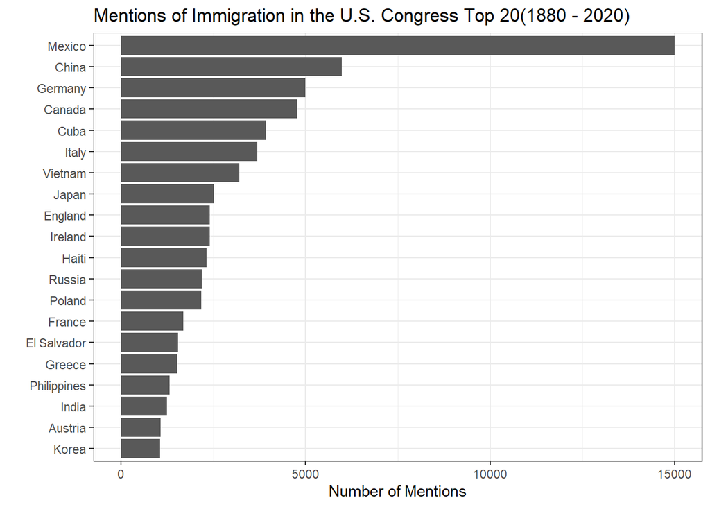

```r
df_imm_counts <- fromJSON("D:/git-project/data/intermediate/imm_country_total_counts.json")

df_imm_counts <- arrange(df_imm_counts, counts)

df_imm_counts <- df_imm_counts |>
  mutate(country = rownames(df_imm_counts))

df_imm_counts$country <- str_to_title(df_imm_counts$country)

p1 <- df_imm_counts |>
  tail(20) |>
  ggplot(aes(x = counts, y = reorder(country, counts))) +
  geom_col() +
  theme_bw() +
  labs(x = "Number of Mentions", y = "", title = "Mentions of Immigration in the U.S. Congress Top 20(1880 - 2020)")
p1
```

# 課題2

## 1. 課題の概要

### ゴール

議会スピーチデータを読み込み、jsonlistに保存する。

## 2. コード

```r
indir <- "D:/git-project/hein_bound_imm"
outdir <- "D:/git-project/data/intermediate/hein_output"


# ファイル一覧の取得
descr_file_paths <- list.files(indir, pattern = "^descr.*\\.txt$", full.names = TRUE)

# 全ファイルの読み込み
descr_split <- map_dfr(descr_file_paths, function(file) {
  lines <- readLines(file)  # 各行をベクトルとして読み込む

  tibble(text = lines) |>
    mutate(file = basename(file)) |>
    separate(text, into = as.character(c(1:15)), sep = "\\|")
})


# ファイル一覧の取得
file_paths <- list.files(indir, pattern = "^speeches.*\\.txt$", full.names = TRUE)

# 全ファイルの読み込み
speeches_split <- map_dfr(file_paths, function(file) {
  lines <- readLines(file)  # 各行をベクトルとして読み込む

  tibble(text = lines) |>
    mutate(file = basename(file)) |>
    separate(text, into = c("id", "text"), sep = "\\|")
})


speech_dates <- descr_split |>
  select(
    id = "1",
    date = "3")

df_speech <-
  left_join(speeches_split, speech_dates, by = "id")

df_speech <- df_speech |>
  filter(date != "18940614")

speech_corpus <- quanteda::corpus(
  df_speech,
  docid_field = "id",
  text_field = "text"
)

sents <- tokens(speech_corpus, what = "sentence")
tokens <- tokens(sents, what = "word")

sents_characters <- lapply(sents, as.character)
tokens_characters <- lapply(tokens, as.character)


outlines <- list(
  id = df_speech$id,
  sents = sents_characters,
  tokens = tokens_characters
)

# write_json(outlines, path =  paste0(outdir, "/speeches.jsonlist"))
```

#### Finding

- textファイルの読み込み
  - 行単位での読み込みread_text()のオプションになかったため、readLines()を使用した
- 列名の処理や命名は改善の余地あり
  - どのカラムがなにを意味しているのかをクリアにする